# Regularization in Phylogenetic Comparative Discrete Character Models

James Boyko

2024-03-30

## Motivation for regularization

As part of my development of corHMM Dredge, I became interested in ways to avoid over-fitting and ensuring well behaved likelihood surfaces. I was familiar with the concept of regularization from my work in machine learning, but had not seen it applied extensively in comparative methods (Khabbazian et al. 2016 being the exception). Thus, I set out to test the performance of regularization in discrete character models across a broad range of possible model structures. In this markdown I will compare regularized results to standard discrete character analysis in corHMM (Boyko and Beaulieu 2021). What I find is major improvements in ways that are expected (exchanging a slight bias for lower variance) and ways that are unexpected (a better behaved likelihood surface). It is not clear to me whether to classify discrete character models as ill-posed problems in the technical sense, but certainly some of the behaviour I demonstrate here is concerning.

One ancillary benefit or regularization is the downweighting of unreasonably high transition rates often found in empirical studies using discrete character models. Specifically, regularization ensures that high rates are heavily penalized and must have far superior likelihoods in order to be supported as the Maximum Regularized Likelihood Estimate (MRLE). I say regularized likelihood estimate since we are not finding the Maximum Likelihood Estimate (MLE) when using regularization. The MLE will find an unbiased estimate, whereas the RLE will find a downwardly biased estimate. However, the MRLE’s variance is far lower than the MLE and it is precisely because of these runaway high rates that can result from low rate simulations.

Here I will demonstrate regularization’s effect on discrete character evolution using corHMM. I utilize a tool in development (corHMM Dredge) to demonstrate the importance of regularization. As such the simulations done here will not be extensive and the analysis conducted will only be on a single empirical dataset (that of Pagel and Meade 2006). At this point in my research corHMM Dredge does not yet have an algorithm to search model structure space, but it does allow for penalty terms (l1 or l2 regularization). l1 regularization adds a penalty based on the absolute value of the parameter estimates and leads to sparser models with parameter estimates being encouraged to go to 0. l2 regularization is less harsh and adds a penalty term based on the square of the parameter estimates, encouraging smaller but not necessarily zero transition rates.

## Profile likelihoods in Pagel and Meade (2006)

### Estimating the models

```r
library(corHMM)
data(primates)
phy <- multi2di(primates[[1]])
data <- primates[[2]]

corhmm_fit <- corHMM(phy = phy,
                     data = data,
                     rate.cat = 1,
                     root.p="yang")
```

```
## State distribution in data:
## States:  0|0 0|1 1|1
## Counts:  29  10  21
## Beginning thorough optimization search -- performing 0 random restarts
## Finished. Inferring ancestral states using marginal reconstruction.
```

```r
corhmm_fit_l1 <- corHMM:::corHMMDredge(phy = phy,
                                       data = data,
                                       max.rate.cat = 1,
                                       pen_type = "l1",
                                       root.p="yang")
```

```
##
## State distribution in data:
## States:  0|0 0|1 1|1
## Counts:  29  10  21
## Beginning thorough optimization search -- performing 0 random restarts
## Finished. Inferring ancestral states using marginal reconstruction.
```

```r
corhmm_fit_l2 <- corHMM:::corHMMDredge(phy = phy,
                                       data = data,
                                       max.rate.cat = 1,
                                       pen_type = "l2",
                                       root.p="yang")
```

```
##
## State distribution in data:
## States:  0|0 0|1 1|1
## Counts:  29  10  21
## Beginning thorough optimization search -- performing 0 random restarts
## Finished. Inferring ancestral states using marginal reconstruction.
```

### Compare parameter estimates

Below are all of the results of the parameter estimates for standard corHMM, l1 regularized corHMM, and l2 regularized corHMM.

The corHMM results represent the true MLE.

```r
corhmm_fit$solution
```

```
##            0|0        0|1        1|1
## 0|0         NA 0.01898216         NA
## 0|1 0.05660493         NA 0.02626401
## 1|1         NA 0.01610317         NA
```

As expected, the l1 regularized results have the lowest parameter estimates of the three.

```r
corhmm_fit_l1$solution
```

```
##            0|0        0|1        1|1
## 0|0         NA 0.01858115         NA
## 0|1 0.05535474         NA 0.02580258
## 1|1         NA 0.01593180         NA
```

And the l2 results are in between l1 and the MLE.

```r
corhmm_fit_l2$solution
```

```
##            0|0        0|1        1|1
## 0|0         NA 0.01896322         NA
## 0|1 0.05650595         NA 0.02623384
## 1|1         NA 0.01609406         NA
```

What is clear is that the point estimates vary only slightly from one another. So why the need for regularization at all? If we examine the profile likelihoods of the parameter estimates of these models we will see that although the point estimates are relatively similar, the likelihood surfaces of unregularized corHMM are quite different from l1 or l2 regularization. Furthermore, within the 95% confidence intervals are values which will seem unreasonably high as a likelihood ridge forms for two of the 4 estimated parameters.

### Calculate profile likeihoods for the 4 estimated parameteres

Here we are going to sample a factor of 10000 above and below the MLE for each parameters. We’re only going to sample 20 points, but as you will see this will still demonstrate the value of regularization.

```r
corhmm_profile <- corHMM:::get_batch_profile_lik(corhmm_obj = corhmm_fit,
                                                 range_factor = 10000,
                                                 n_points = 20,
                                                 ncores = 10,
                                                 dredge = FALSE)

l1_profile <- corHMM:::get_batch_profile_lik(corhmm_obj = corhmm_fit_l1,
                                             range_factor = 10000,
                                             n_points = 20,
                                             ncores = 10,
                                             dredge = TRUE)

l2_profile <- corHMM:::get_batch_profile_lik(corhmm_obj = corhmm_fit_l2,
                                             range_factor = 10000,
                                             n_points = 20,
                                             ncores = 10,
                                             dredge = TRUE)
```

## Plot profile likeihoods for the 4 estimated parameteres

In the plots below the dashed line is 1.92 likelihood units below the maximum likelihood estimate (or maximum regularized likelihood estimate). Anything parameter estimate with a likelihood estimate above this dashed line is within the 95% confidence interval.

```
## [1] "unregularized result"
```

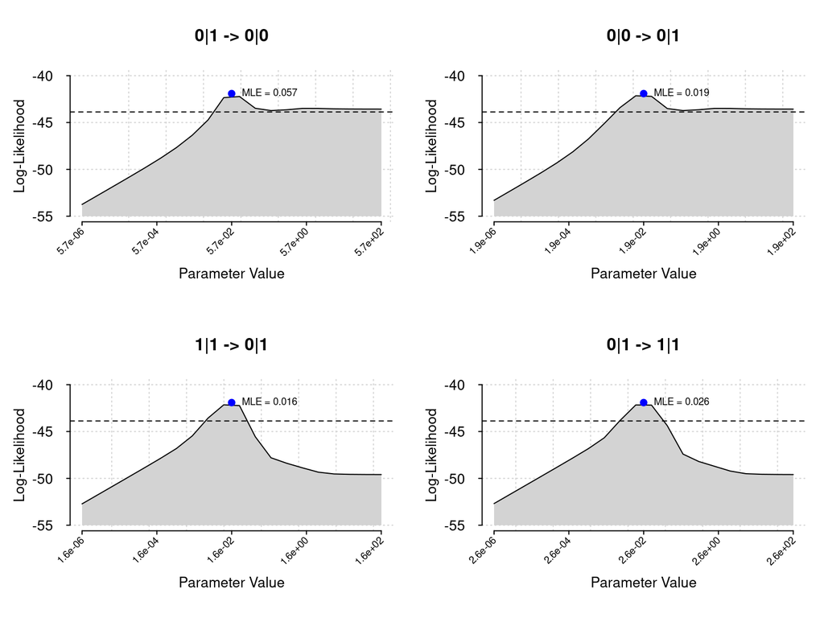

```
## [1] "l1 regularized result"
```

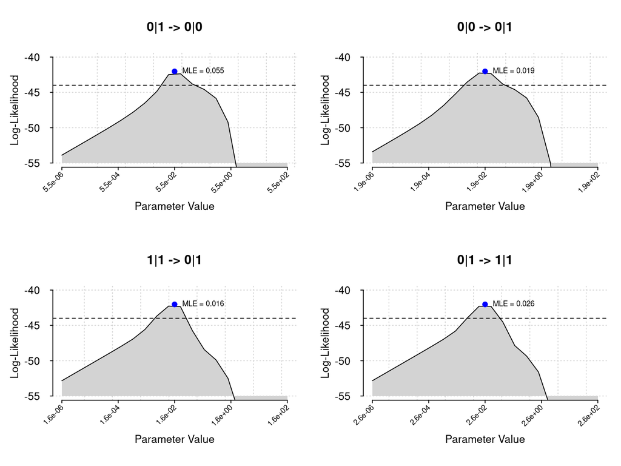

```
## [1] "l2 regularized result"
```

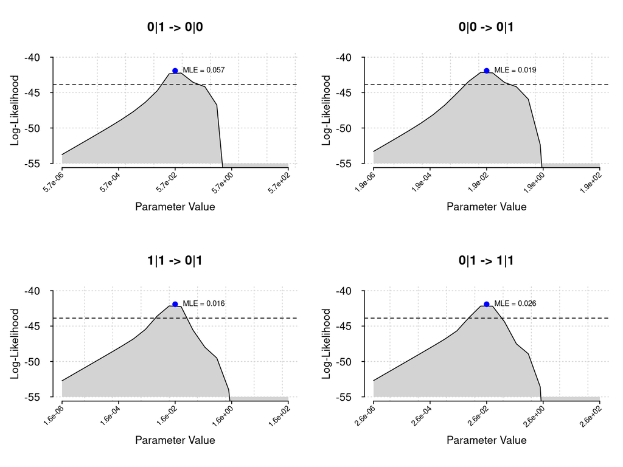

Thus, even though we sampled a factor of 10000 above and below the point estimate (e.g., 0|1 -> 0|0 has an MLE of 0.057 transitions per million years and we sampled between 0.0000057 and 570 transitions per million years) there is a ridge of values greater than the MLE which lie above the dashed line and are therefore within the 95% confidence interval.

### Detailed examination of 0|1 -> 0|0

```
## [1] "Maximum lnLik"
```

```
## [1] -41.90862
```

```
## [1] "Profile likelihood table"
```

```
##       par_value     lnLik
## 1  5.660493e-06 -53.74317
## 2  1.492474e-05 -52.77228
## 3  3.935134e-05 -51.79914
## 4  1.037557e-04 -50.82008
## 5  2.735677e-04 -49.82565
## 6  7.213024e-04 -48.79214
## 7  1.901823e-03 -47.66555
## 8  5.014442e-03 -46.35173
## 9  1.322133e-02 -44.72498
## 10 3.486004e-02 -42.33908
## 11 9.191376e-02 -42.22437
## 12 2.423445e-01 -43.47805
## 13 6.389778e-01 -43.72252
## 14 1.684762e+00 -43.63661
## 15 4.442128e+00 -43.48496
## 16 1.171234e+01 -43.49047
## 17 3.088135e+01 -43.53607
## 18 8.142335e+01 -43.55488
## 19 2.146849e+02 -43.56205
## 20 5.660493e+02 -43.56478
```

```
## [1] "lnLik"
```

```
## [1] 43.56478
```

```
## [1] "Fixed parameter value for 0|1 -> 0|0"
```

```
## [1] 566.0493
```

```
## [1] "Optimized values of the remaining transition rates"
```

```
##   0|0 -> 0|1   1|1 -> 0|1   0|1 -> 1|1
## 195.12517821   0.01690046   0.02429494
```

```
## [1] "corHMM fit with fixed parameters"
```

```
##                0|0 -> 0|1   1|1 -> 0|1   0|1 -> 1|1
## 566.04925568 195.12517821   0.01690046   0.02429494
```

```r
ridge_fit <- corHMM::corHMM(phy = phy,
               data = data,
               rate.cat = 1,
               root.p="yang",
               p = p)
```

```
## State distribution in data:
## States:  0|0 0|1 1|1
## Counts:  29  10  21
## Calculating likelihood from a set of fixed parameters
## Finished. Inferring ancestral states using marginal reconstruction.
```

The values of this transition rate matrix are quite different from the MLE (which is what would usually be interpreted as a point estimate). But, these transition rates which lie along the ridge are well within the 1.92 likelihood units of the MLE.

```r
print("Original MLE fit")
```

```
## [1] "Original MLE fit"
```

```r
corhmm_fit
```

```
##
## Fit
##       -lnL      AIC     AICc Rate.cat ntax
##  -41.90862 91.81725 92.54452        1   60
##
## Legend
## [1] "T1|T2"
## [1] "0|0" "1|0" "0|1" "1|1"
##
## Rates
##            0|0        0|1        1|1
## 0|0         NA 0.01898216         NA
## 0|1 0.05660493         NA 0.02626401
## 1|1         NA 0.01610317         NA
##
## Arrived at a reliable solution
```

```r
print("Parameter values from the ridge")
```

```
## [1] "Parameter values from the ridge"
```

```r
ridge_fit
```

```
##
## Fit
##       -lnL      AIC     AICc Rate.cat ntax
##  -43.56478 95.12956 95.85683        1   60
##
## Legend
## [1] "T1|T2"
## [1] "0|0" "1|0" "0|1" "1|1"
##
## Rates
##          0|0          0|1        1|1
## 0|0       NA 195.12517821         NA
## 0|1 566.0493           NA 0.02429494
## 1|1       NA   0.01690046         NA
##
## Arrived at a reliable solution
```

## Effect on ancestral state reconstruction

Transition rates are not necessarily representative of the characters’ histories. In fact, it is tempting to think that the reason that these characters are “free” (so to speak) to be range across factors of 1000 or more is because they don’t actually occur in a typical character history. However, this is not the case for these models as I will show using stochastic mapping. Of course, the point estimates associated with the MLE will be as well behaved as any regularized model (though this is not guaranteed to be generally true, it is true for this dataset). The point of these simulations is to show that well within 95% confidence intervals are parameter estimates which would lead to wildly different interpretations. However, this is only the case for unregularized Markov models.

*Note that I would run more extensive stochastic character simulations if the rates were not prohibitively fast. I mean this in the sense that the transition rates are so fast that is difficult for stochastic mapping code to even produce a single character history since there are so many transitions that need to be accounted for.

### Marginal reconstruction

To begin with I will plot the marginal ancestral state reconstruction for the “ridge” model and the MLE model.

```r
print("Original MLE fit")
```

```
## [1] "Original MLE fit"
```

```r
corhmm_fit
```

```
##
## Fit
##       -lnL      AIC     AICc Rate.cat ntax
##  -41.90862 91.81725 92.54452        1   60
##
## Legend
## [1] "T1|T2"
## [1] "0|0" "1|0" "0|1" "1|1"
##
## Rates
##            0|0        0|1        1|1
## 0|0         NA 0.01898216         NA
## 0|1 0.05660493         NA 0.02626401
## 1|1         NA 0.01610317         NA
##
## Arrived at a reliable solution
```

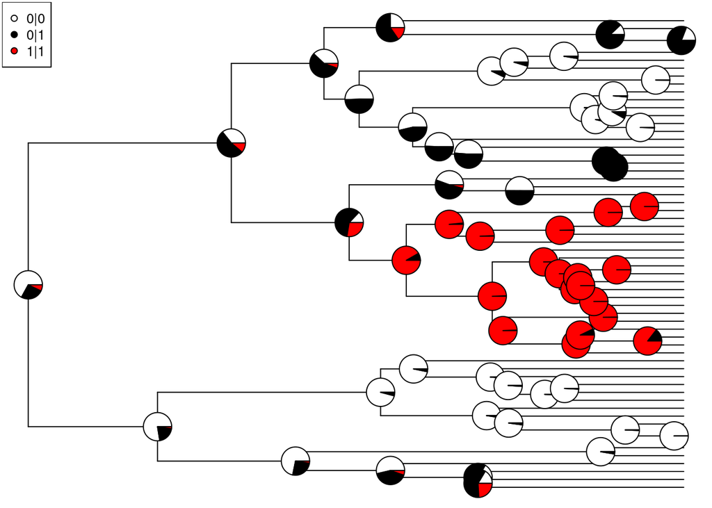

```r
par(mar=c(.1,.1,.1,.1))
corHMM::plotRECON(corhmm_fit$phy, corhmm_fit$states, pie.cex = 1, show.tip.label = FALSE)
```

```r
print("Parameter values from the ridge")
```

```
## [1] "Parameter values from the ridge"
```

```r
ridge_fit
```

```
##
## Fit
##       -lnL      AIC     AICc Rate.cat ntax
##  -43.56478 95.12956 95.85683        1   60
##
## Legend
## [1] "T1|T2"
## [1] "0|0" "1|0" "0|1" "1|1"
##
## Rates
##          0|0          0|1        1|1
## 0|0       NA 195.12517821         NA
## 0|1 566.0493           NA 0.02429494
## 1|1       NA   0.01690046         NA
##
## Arrived at a reliable solution
```

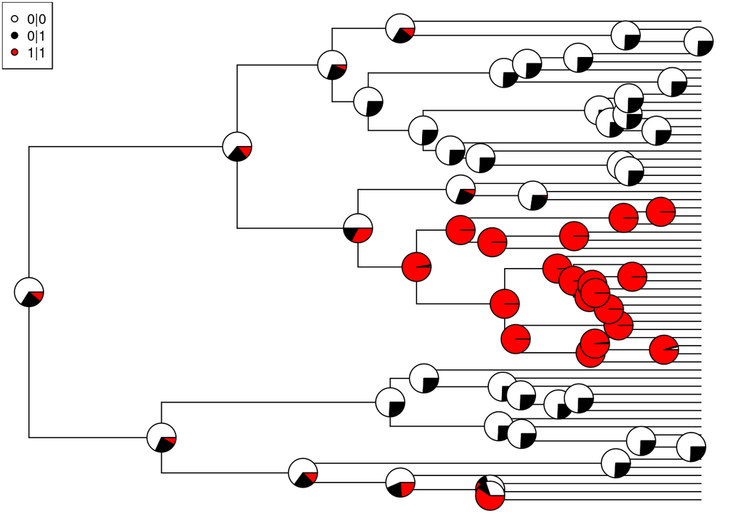

```r
par(mar=c(.1,.1,.1,.1))
corHMM::plotRECON(ridge_fit$phy, ridge_fit$states, pie.cex = 1, show.tip.label = FALSE)
```

At first glance, it seems that some differences exist, but most interpretations from this graph would likely remain unchanged. However, any place where ancestral states were 0|0 or 0|1 are almost always 3/4 in favor of 0|0. This is because the information has decayed so rapidly (due to high rates) at those nodes that all that can be inferred is equilibrium frequencies (see Boyko and Beaulieu 2021). One can conclude that there is a great deal more uncertainty in the ridge plot than in the MLE and significantly less information from the tip states being used in the ridge ASR.

### Stochastic mapping and too many transitions

Let’s now examine explicit character histories. The above marginal reconstructions are useful for getting a sense of the decay of information, but not necessarily indicative of a “biological effect.” Something which is more clear is a simulated character history which is an iteration of how a model such as this could produce the extant diversity we see today.

Below is the MLE point estimate. The character history is entirely reasonable and in my opinion, shows no signs to be concerned.

```
## no colors provided. using the following legend:
##       0|0       0|1       1|1
##   "black" "#DF536B" "#61D04F"
```

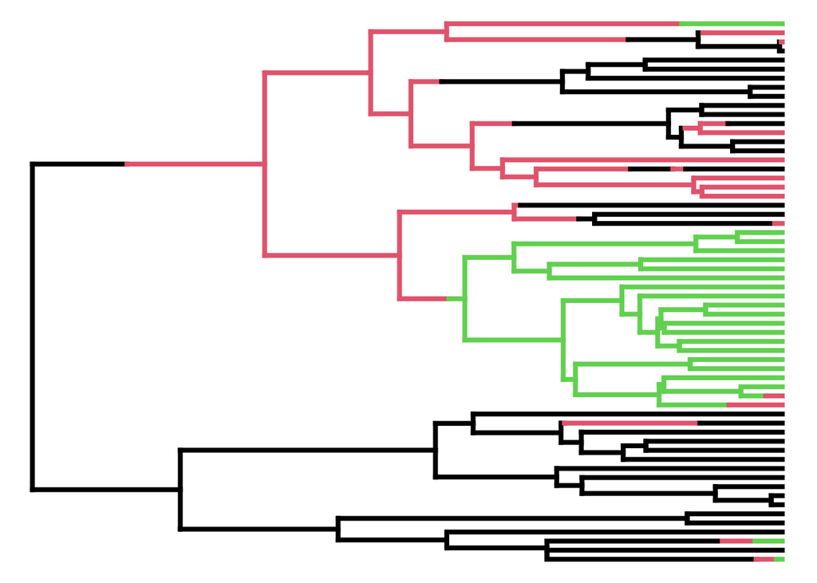

```r
model <- corhmm_fit$solution
simmap_mle <- makeSimmap(tree=phy, data=data, model=model, rate.cat=1, nSim=1, nCores=1)
phytools::plotSimmap(simmap_mle[[1]], fsize = 0.01, lwd = 4)
```

The story is entirely different for the ridge estimate. The character history is shows several places where the number of transitions is too high to count. And this is of course a genuine empirical dataset. That means, within the 95% confidence intervals of the MLE, is a parameter estimate which suggests 1000s of transitions between the presence and absence of multimale systems along several different lineages of primate. This is unreasonable to any biologist, but I stress is well within the possible explanations of the data if one uses an unregularized model. The reason the regularized model preforms so well is because of its favorable bias-variance trade-off and the effect of greater generalizabiliy on ancestral state reconstruction. I discuss this in further detail different vignette.

```
## no colors provided. using the following legend:
##       0|0       0|1       1|1
##   "black" "#DF536B" "#61D04F"
```

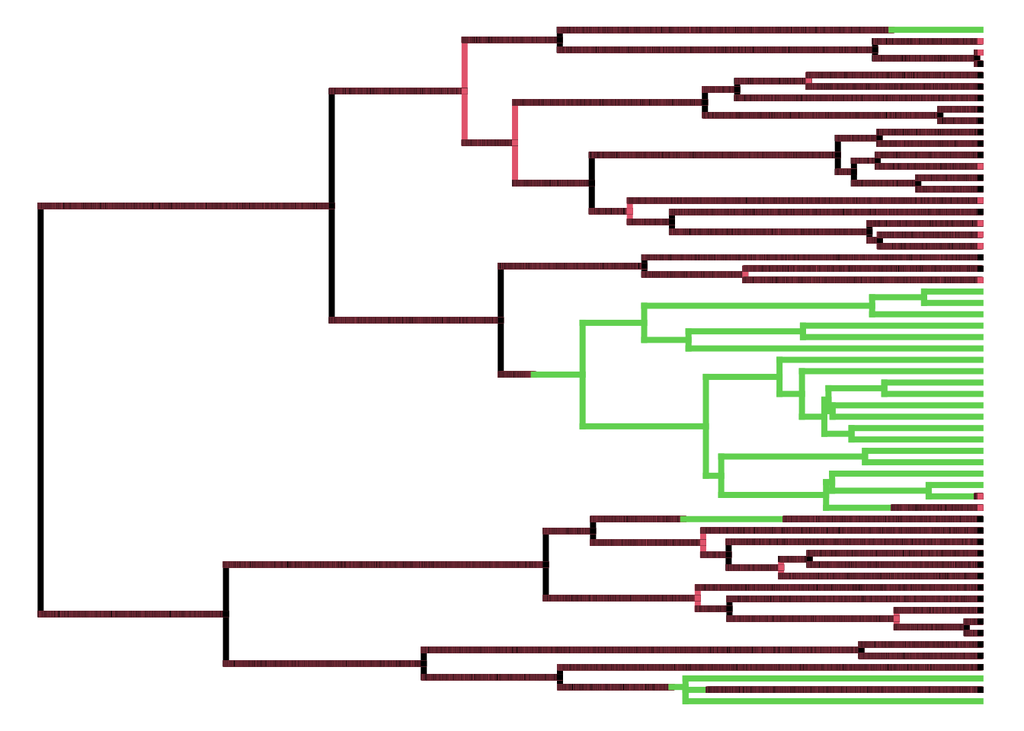

```r
model <- ridge_fit$solution
simmap_ridge <- makeSimmap(tree=phy, data=data, model=model, rate.cat=1, nSim=1, nCores=1, max.attempt = 100000)
phytools::plotSimmap(simmap_ridge[[1]], fsize = 0.01, lwd = 4)
```

## Transition rates for unobserved states

Next I will demonstrate was perhaps an even more exceptional result. This section is related to estimating rates when there are no unobserved instances of a state combination. For example, in the dataset we’ve been using thus far, there are no instances of the presence of estrus advertisement, when the mating system is monogamous (1|0 state combination). There has been some debate as to whether it is valid to estimate transition rates when the state combination is unobserved. In fact, Boyko and Beaulieu (2022) made an argument for not estimating these transition rates and corHMM was changed to reflect that belief - now by default unobserved state combinations are removed from the transition rate matrix. Nonetheless, it remains unclear whether it is valid to estimate these transition rates and I do not purport to solve that problem, though, based on what will be presented below, I’d wager we are correct in dropping the unobserved state combinations.

### An alternative root prior

The choice of root prior is an underappreciated aspect of discrete character model fitting. This choice can have a rather large impact on your results and generally there is little exploration beyond default. The default for corHMM is the “yang” (Yang 2006), but for corHMMDredge I have changed the default to “maddfitz” FitzJohn et al (2009) which better reflects a truly uninformative prior than either flat or “yang.” I bring this up because the behaviour of this next section is even worse with the “yang” prior, but the result is not saved by the “maddfitz” prior.

I start by fitting the four models we will be examining. We have two corHMM models, the “full” model includes the unobserved state combinations and the collapsed does not. I only include l1 regularization in this example as my point is no longer about contrasting different forms of regularization. l2 regularization will preform about as well, though admittedly I did not examine any potential differences in-depth.

### Model fitting

Something worth noting is that the fitting of the “full” models is incredibly finicky for unregularized versions of discrete character models. Though it is always best practices to have multiple random starts when fitting a model, here I would argue it’s necessary as even small diferences in the lnLik will have massive impacts on the transition rate estimates. This is not nearly as much of a problem for the regularized model.

```r
# unregularized
corhmm_fit_full <- corHMM(phy = phy,
                          data = data,
                          rate.cat = 1,
                          root.p="maddfitz",
                          collapse = FALSE,
                          upper.bound = 1e10,
                          nstarts = 10,
                          n.cores = 10)
```

```
## State distribution in data:
## States:  0|0 1|0 0|1 1|1
## Counts:  29  0   10  21
## Beginning thorough optimization search -- performing 10 random restarts
## Finished. Inferring ancestral states using marginal reconstruction.
```

```r
corhmm_fit_collapsed <- corHMM(phy = phy,
                               data = data,
                               rate.cat = 1,
                               root.p="maddfitz",
                               collapse = TRUE,
                               upper.bound = 1e10,
                               nstarts = 10,
                               n.cores = 10)
```

```
## State distribution in data:
## States:  0|0 0|1 1|1
## Counts:  29  10  21
## Beginning thorough optimization search -- performing 10 random restarts
## Finished. Inferring ancestral states using marginal reconstruction.
```

```r
# regularized
corhmm_fit_l1_full <- corHMM:::corHMMDredge(phy = phy,
                                            data = data,
                                            max.rate.cat = 1,
                                            pen_type = "l1",
                                            root.p="maddfitz",
                                            collapse = FALSE)
```

```
## State distribution in data:
## States:  0|0 1|0 0|1 1|1
## Counts:  29  0   10  21
## Beginning thorough optimization search -- performing 0 random restarts
## Finished. Inferring ancestral states using marginal reconstruction.
```

```r
corhmm_fit_l1_collapsed <- corHMM:::corHMMDredge(phy = phy,
                                                 data = data,
                                                 max.rate.cat = 1,
                                                 pen_type = "l1",
                                                 root.p="madfitz",
                                                 collapse = TRUE)
```

```
## State distribution in data:
## States:  0|0 0|1 1|1
## Counts:  29  10  21
## Beginning thorough optimization search -- performing 0 random restarts
## Finished. Inferring ancestral states using marginal reconstruction.
```

Now let us take a look at the results. What I would suggest is that there is little to no information estimate transitions to and from unobserved state combinations. I would go so far as to claim this is an “ill-posed” problem, which is exactly the reason we would apply regularization in other contexts.

I will first clean these models up by dropping any parameters which are below 1e-5. This is done for a couple of reasons. First it will make the comparisons much easier. Second, these are parameters that I would drop during a corHMM dredge run anyways, as they are not needed to explain the data.

```r
# drop low params
corhmm_fit_full$solution[corhmm_fit_full$solution < 1e-5] <- NA
corhmm_fit_full$index.mat[is.na(corhmm_fit_full$solution)] <- NA
corhmm_fit_full$index.mat[!is.na(corhmm_fit_full$index.mat)]<-1:sum(!is.na(corhmm_fit_full$solution))
# regularized
corhmm_fit_l1_full$solution[corhmm_fit_l1_full$solution < 1e-5] <- NA
corhmm_fit_l1_full$index.mat[is.na(corhmm_fit_l1_full$solution)] <- NA
corhmm_fit_l1_full$index.mat[!is.na(corhmm_fit_l1_full$index.mat)] <- 1:3 # hardcoding indices, yikes
```

Now let’s look at the regularized results.

```
## [1] "l1 collapsed transition rate matrix"
```

```
##            0|0        0|1       1|1
## 0|0         NA 0.01775962        NA
## 0|1 0.05199899         NA 0.0258025
## 1|1         NA 0.01318424        NA
```

```
## [1] "l1 full transition rate matrix"
```

```
##            0|0 1|0         0|1 1|1
## 0|0         NA  NA 0.007428248  NA
## 1|0         NA  NA          NA  NA
## 0|1 0.08223337  NA          NA  NA
## 1|1         NA  NA 0.026076465  NA
```

```
## [1] "unregularized collapsed transition rate matrix"
```

```
##            0|0         0|1   1|1
## 0|0         NA 0.007664179    NA
## 0|1 0.08331563          NA 1e-09
## 1|1         NA 0.026160661    NA
```

```
## [1] "unregularized full transition rate matrix"
```

```
##              0|0 1|0         0|1 1|1
## 0|0           NA  NA 0.007664938  NA
## 1|0 9.761774e+09  NA          NA  NA
## 0|1 8.323702e-02  NA          NA  NA
## 1|1           NA  NA 0.026150698  NA
```

Again, for the most part we see concordance! However, what has happened in all of my tests is that there is at least one extra parameter estimated to or from the unobserved state combination. Surely that means it is estimable right? Unfortunately, I would say no - there is just no information to estimate the rates in this case.

### Profile likelihoods

```r
# unregularized
corhmm_profile_full <- corHMM:::get_batch_profile_lik(corhmm_obj = corhmm_fit_full,
                                                      range_factor = 10000,
                                                      n_points = 20,
                                                      ncores = 10,
                                                      dredge = FALSE)
# regularized
l1_profile_full <- corHMM:::get_batch_profile_lik(corhmm_obj = corhmm_fit_l1_full,
                                                  range_factor = 10000,
                                                  n_points = 20,
                                                  ncores = 10,
                                                  dredge = TRUE)
```

Plotting we see (a) clear ridge(s) for the unregularized version. This ridge is not present in the regularized result because that problematic and uninformative parameter is dropped from the model.

```
## [1] "unregularized result"
```

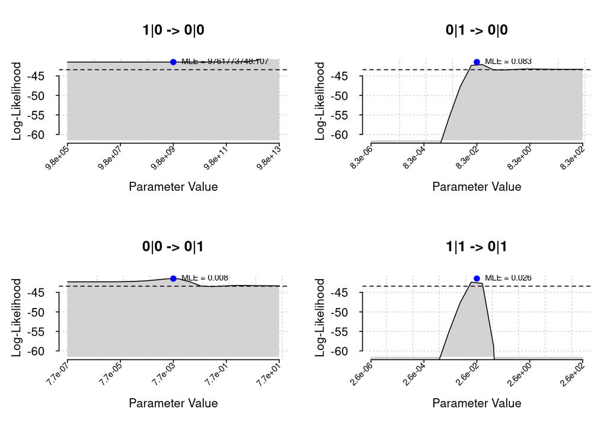

```
## [1] "l1 regularized result"
```

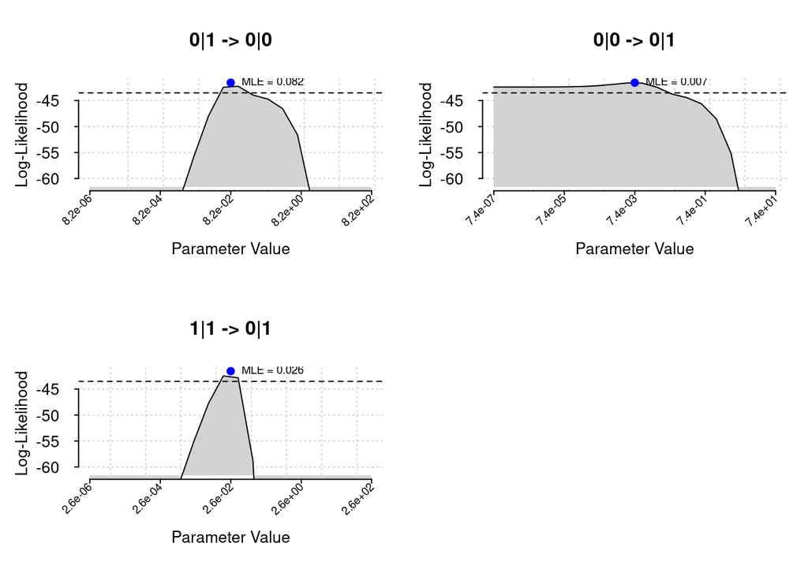

Once again, the results are far more consistent when using a regularized model. And if this model were run 100 times, we’d likely find at least a dozen different estimates for the unregularized model, even with multiple random starting values. This should be concerning.

### Is it ever possible to estimate transition rates to unobserved state combinations

It is straightforward enough to imagine situations where one forces transitions between an unobserved intermediate state. In fact, we do this with hidden Markov models all the time (precursor model of Mazzari et al. 2012). But, the difference there is that those are known to be unobserved states and are coded differently than if one were to claim they were an observed state without any observations. I doubt that estimating transitions to and from unobserved state combinations is possible. And even if it is, it is likely to be unidentifiable with other models that use hidden states. Furthermore, whether we can test such a model outside the context of hidden Markov models is dubious. Imagine an intermediate unobserved state combination, this model presupposes a different data structure (say 4 possible state combinations) than when it is not included (3 possible state combinations). If coded as a hidden Markov problem, the inference is valid because the data is the same, but if we set the 4th combination to 0 observations, then we are saying the data is fundamentally different. It would be worth looking into this further at a later date.

## Conclusion

Parameter estimation is not a trivial matter. In phylogenetic comparative methods we base entire research programs on the outcomes of model fitting. And, though often ignored, uncertainty around our point estimates are important to consider. This can give us insight into how strong of an inference we should be drawing from our model. As Boyko and 0’Meara (2024) said: “Importantly, the biological interpretation of an extinction rate of certainly 0 will differ massively than if it were treated as possibly 0.” Though we said extinction rate, we could have easily generalized the sentiment to say “a certain parameter estimate” versus “an uncertain parameter estimate.” I have shown above how parameter uncertainty can massively influence biological interpretations of ancestral state reconstructions. This choice is made primarily because ASR depends entirely on the model being used for the reconstruction. And the model we choose to use has uncertainty around its estimate. Unfortunately, the Markov models used to date may have a great deal more uncertainty than has been previously appreciated. Nonetheless, I believe that regularization is a perfectly reasonable solution and that the slight bias is small price to pay well behaved likelihood surfaces and more certain parameter estimates.